# Lab 13 - Creating a detailed report with explanations from the NEON MAG dat

### 3B. MAG richness vs latitude

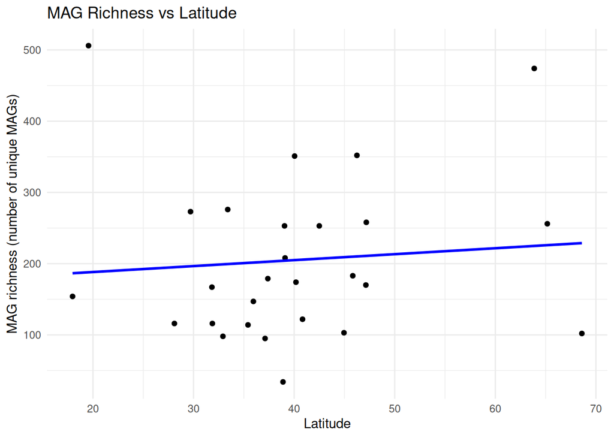

```r
ggplot(richness, aes(x = latitude, y = mag_richness)) +
  geom_point() +
  geom_smooth(method = "lm", se = FALSE, color = "blue") +
  theme_minimal() +
  labs(
    title = "MAG Richness vs Latitude",
    x = "Latitude",
    y = "MAG richness (number of unique MAGs)"
  )
```

## 4. Spatial Patterns + Environment: Richness vs pH and Elevation

Now let’s connect spatial patterns with environment by looking at site-level MAG richness vs mean soil pH and elevation.

```r
richness_env <- NEON |>
  filter(
    !is.na(site_id),
    !is.na(bin_id)
  ) |>
  group_by(site_id) |>
  summarise(
    mag_richness = n_distinct(bin_id),
    mean_pH      = mean(soil_in_waterp_h, na.rm = TRUE),
    mean_temp    = mean(soil_temp,        na.rm = TRUE),
    mean_moist   = mean(soil_moisture,    na.rm = TRUE),
    mean_elev    = mean(elevation,        na.rm = TRUE),
    latitude     = mean(decimal_latitude,  na.rm = TRUE),
    longitude    = mean(decimal_longitude, na.rm = TRUE),
    .groups = "drop"
  )

richness_env
```

```
# A tibble: 27 × 8
   site_id mag_richness mean_pH mean_temp mean_moist mean_elev latitude
   <chr>          <int>   <dbl>     <dbl>      <dbl>     <dbl>    <dbl>
 1 BONA             256    4.07      8.20     2.30       434.      65.2
 2 CLBJ             276    5.14     22.1      0.138      282.      33.4
 3 CPER             122    6.90     24.8      0.0736    1645.      40.8
 4 DCFS             258    6.52     19.2      0.316      561.      47.2
 5 DEJU             474    4.82      6.74     0.517      522.      63.9
 6 DSNY             116    4.49     25.6      0.227       19.3     28.1
 7 GUAN             154    7.73     28.4      0.481      135.      18.0
 8 HARV             253    3.75     16.7      2.66       274.      42.5
 9 KONZ             208    6.79     25.0      0.195      404.      39.1
10 LENO             167    5.08     25.1      0.396       11.7     31.8
# ℹ 17 more rows
# ℹ 1 more variable: longitude <dbl>
```

### 4A. MAG richness vs mean soil pH

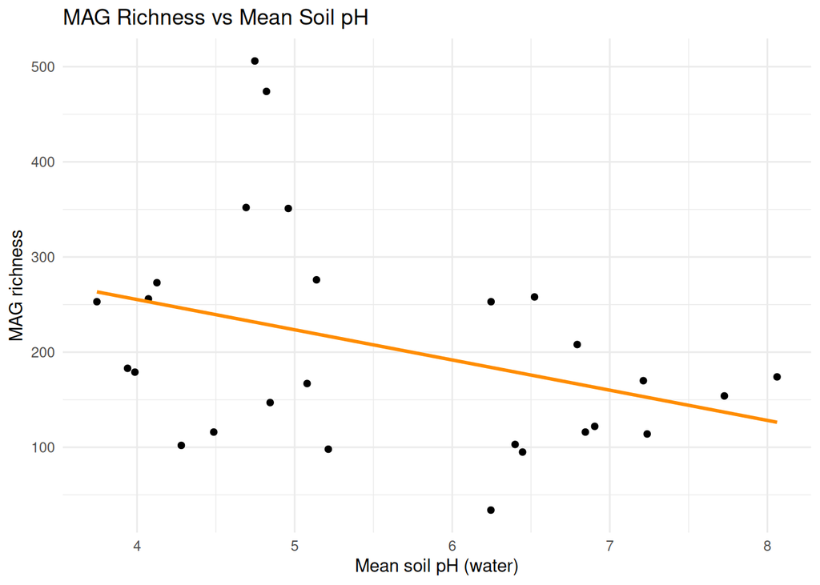

```r
ggplot(richness_env, aes(x = mean_pH, y = mag_richness)) +
  geom_point() +
  geom_smooth(method = "lm", se = FALSE, color = "darkorange") +
  theme_minimal() +
  labs(
    title = "MAG Richness vs Mean Soil pH",
    x = "Mean soil pH (water)",
    y = "MAG richness"
  )
```

Here I related MAG richness to mean soil pH at each site. Each point represents one NEON site, with its average soil pH on the x-axis and MAG richness on the y-axis. The fitted line shows the overall trend between pH and richness. If richness peaks at intermediate pH values and drops at very low or high pH, that would suggest that extreme acidity or alkalinity reduces microbial genomic diversity. Overall, this plot links a key soil chemistry variable (pH) to the number of genomes recovered and helps show how environmental filtering shapes soil microbial communities.

### 4B. MAG richness vs elevation

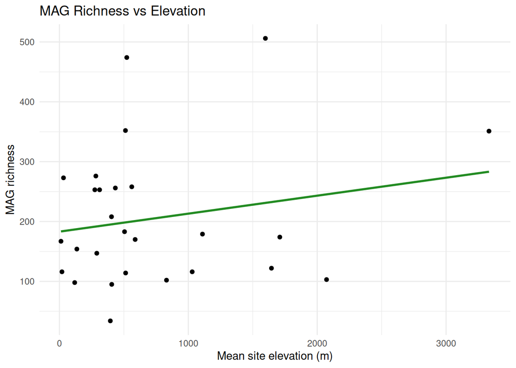

```r
ggplot(richness_env, aes(x = mean_elev, y = mag_richness)) +
  geom_point() +
  geom_smooth(method = "lm", se = FALSE, color = "forestgreen") +
  theme_minimal() +
  labs(
    title = "MAG Richness vs Elevation",
    x = "Mean site elevation (m)",
    y = "MAG richness"
  )
```

This plot explores how MAG richness changes with elevation. Each point is a NEON site, plotted by its mean elevation and MAG richness. The trend line indicates whether richness tends to increase, decrease, or stay relatively constant with elevation. A decreasing trend would be consistent with the idea that harsher conditions at high elevation (colder temperatures, thinner soils) may limit microbial diversity, while a flat trend would suggest that elevation is less important than other factors such as local soil chemistry.